# Weight Lifting Machine Learning

Michael Liquori

Sunday, August 24, 2014

## Executive Summary

We attempt to answer one question:

**1. Can we predict whether weightlifting exercises are done correctly or not using the motion-data available?**

In order to accomplish this we apply Random Forest modeling to the Weight Lifting Exercise Dataset available at http://groupware.les.inf.puc-rio.br/har. This model was decided to be the best by the original authors of the data, who state that, “because of the characteristic noise in the sensor data, we used a Random Forest approach.” (http://groupware.les.inf.puc-rio.br/public/papers/2013.Velloso.QAR-WLE.pdf)

## Pre-Processing

Read in the data:

```r
training<-read.csv("pml-training.csv")
testing<-read.csv("pml-testing.csv")
```

Check for missing data (NAs):

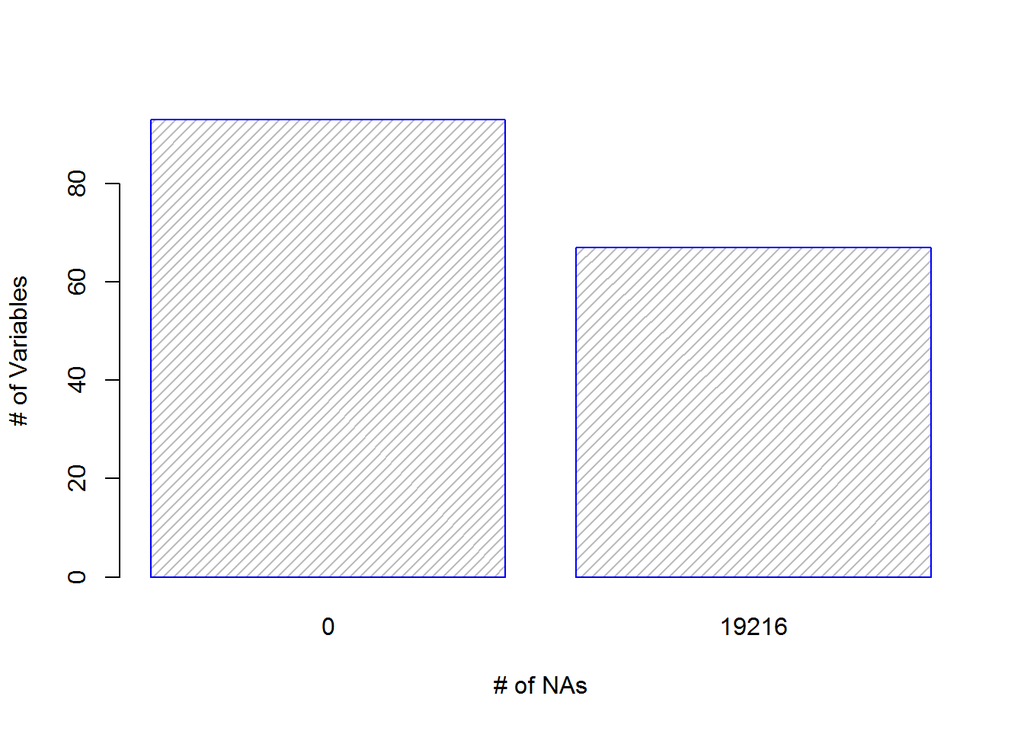

```r
sumNA<-function(x){
  sum(is.na(x))
}
x<-apply(training,2,sumNA)
barplot(table(x),border="blue", density=c(20:1),xlab="# of NAs",ylab="# of Variables")
```

Since so many columns (variables) are almost entirely NA, we will eliminate those columns:

```r
train1 <- training[,which(apply(training,2,sumNA)==0)]
dim(train1)
```

```
## [1] 19622    93
```

Then, we remove all non-motion data, including non-numeric variables and timestamps, and finally, add back our dependent variable **classe**.

```r
numCols <- sapply(train1, is.numeric)
train2<-cbind(train1$classe,train1[,numCols])
colnames(train2)[1]<-"classe"
train2<-train2[,-c(2:5)]
```

**Create test and train sets: (for cross-validation)**

```r
library(caret)
inTrain<- createDataPartition(y=train2$classe, p=0.75, list=FALSE)
trainset<-train2[inTrain,]
testset<-train2[-inTrain,]
```

## Model, Out-Of-Sample Error Estimation

We expect the out-of-sample error to be estimated by the OOB estimate of error rate given from our Random Forest model. This is because each tree is constructed using a different bootstrap sample, as explained here: http://www.stat.berkeley.edu/~breiman/RandomForests/cc_home.htm#ooberr.

```r
library(randomForest)
fit1<-randomForest(classe~.,data=trainset)
print(fit1)
```

```
##
## Call:
##  randomForest(formula = classe ~ ., data = trainset)
##                Type of random forest: classification
##                      Number of trees: 500
## No. of variables tried at each split: 7
##
##         OOB estimate of  error rate: 0.5%
## Confusion matrix:
##      A    B    C    D    E class.error
## A 4183    1    0    0    1   0.0004779
## B   12 2830    6    0    0   0.0063202
## C    0   17 2548    2    0   0.0074016
## D    0    0   25 2384    3   0.0116086
## E    0    0    1    6 2699   0.0025868
```

**Estimated Out-Of-Sample Error Rate: Varies between 0.39%-0.51% on each run**

## Cross-Validation, Out-Of-Sample Error

Cross-validating against my created testing data to get a closer estimate of out-of-sample error:

```r
pred1<-predict(fit1,newdata=testset)
confusionMatrix(pred1,testset$classe)
```

```
## Confusion Matrix and Statistics
##
##           Reference
## Prediction    A    B    C    D    E
##          A 1395    6    0    0    0
##          B    0  943   13    0    0
##          C    0    0  841   15    1
##          D    0    0    1  788    4
##          E    0    0    0    1  896
##
## Overall Statistics
##
##                Accuracy : 0.992
##                  95% CI : (0.989, 0.994)
##     No Information Rate : 0.284
##     P-Value [Acc > NIR] : <2e-16
##
##                   Kappa : 0.989
##  Mcnemar's Test P-Value : NA
##
## Statistics by Class:
##
##                      Class: A Class: B Class: C Class: D Class: E
## Sensitivity             1.000    0.994    0.984    0.980    0.994
## Specificity             0.998    0.997    0.996    0.999    1.000
## Pos Pred Value          0.996    0.986    0.981    0.994    0.999
## Neg Pred Value          1.000    0.998    0.997    0.996    0.999
## Prevalence              0.284    0.194    0.174    0.164    0.184
## Detection Rate          0.284    0.192    0.171    0.161    0.183
## Detection Prevalence    0.286    0.195    0.175    0.162    0.183
## Balanced Accuracy       0.999    0.995    0.990    0.989    0.997
```

## Variable Importance, Plot Top 20 Variables:

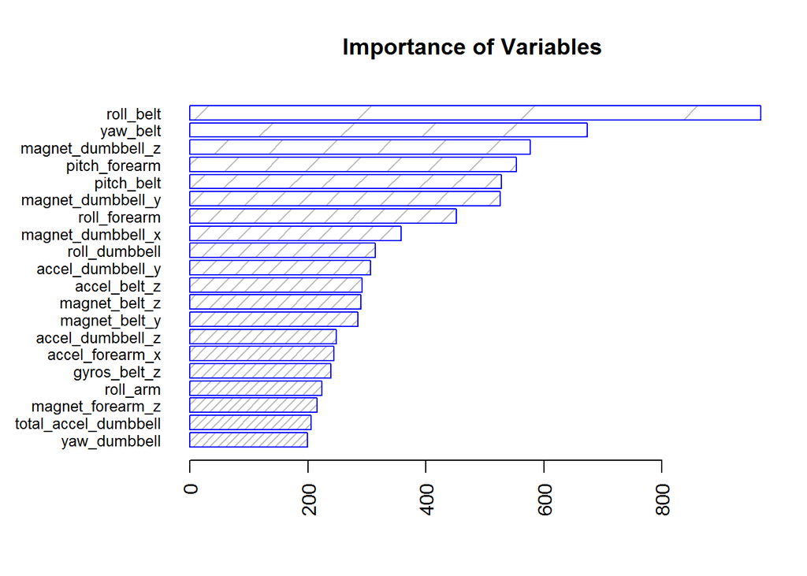

```r
imp<-importance(fit1)
imp2<-imp[order(imp, decreasing=TRUE),]
imp2.df<-data.frame(imp2)
par(las=2)
par(mar=c(5,8,4,2))
barplot(imp2.df$imp2[20:1], horiz=TRUE, main="Importance of Variables",
        names.arg=row.names(imp2.df)[20:1],
        border="blue", density=c(20:1),cex.names=0.8)
```

## Predict 20 observation test dataset

```r
pred2<-predict(fit1,newdata=testing)
```

**100% accuracy achieved.** (Results not displayed to avoid giving away answers to future students)